# how_to_use_n6

- How to Use STM32N6570-DK
  - Flash Boot and Dev Boot Configurations
  - Flashing Binaries
  - Loading Code in RAM from Debuggers
  - Toolchain Tips
  - Known Limitations

# How to Use STM32N6570-DK

Being a flash-less secured device, some precautions must be taken while using the STM32N6570-DK, either running in flash boot configuration or dev boot configuration.

## Flash Boot and Dev Boot Configurations

There are three modes/configurations described below and illustrated by the following figure:

- **Serial boot configuration:**
  - This configuration is not used in this package.
  - The image is loaded from a serial interface.
  - The BootROM code supports the following types of serial boot interfaces:
    - USB boot
    - UART boot
- **Flash boot configuration:**
  - BOOT0 on position 2
  - BOOT1 on position 2
  - Uses a boot loader to copy the application into RAM and then execute.
  - Debugging is not possible in this mode.
  - System reset is possible in this mode.
- **Dev boot configuration:**
  - BOOT1 on position 3
  - BOOT0 position has no impact when BOOT1 is on 3.
  - The debugger will load the application into RAM.
  - System reset is not possible; it’s recommended to set the reset button of your favorite toolchain to perform a software reset rather than a system reset or to use a macro that will reload the application.
  - This BOOT1 position must be used to flash any firmware.

[figure not shown]

## Flashing Binaries

Please locate the Bin folder in your X-CUBE-AUDIO Kit package.

In this folder, please locate the Fast & Secure Boot Loader called `X-CUBE-AUDIO-KIT-STM32N6570-DK-FSBL.bin`. This bootloader after reset will upload and run automatically application firmware stored in external memory to RAM. Therefore, in order to flash your application, follow these steps:

1. Put BOOT0 and BOOT1 buttons of the STM32N6570-DK in position 3 to flash the device.
2. Flash `X-CUBE-AUDIO-KIT-STM32N6570-DK-FSBL.bin`.
3. Flash the application firmware.
4. Put BOOT0 & BOOT1 buttons in position 2 to go into flash boot configuration.
5. Reset the board and connect.

In Bin, please locate the ac_flash_firmware.sh flasher. This script is given as an example to help the flashing process:

- It locates all the binaries in a given folder.
- Asks the user which one should be flashed.
- Signs as trusted/secured.
- Flashes the requested binary (boot loader or application).

A similar script is also provided inside the application folder to do the same using a freshly compiled binary; the flasher.sh file.

## Loading Code in RAM from Debuggers

In this case, please use the dev boot configuration button positions.

After that, please compile the chosen target and start the debugger. The code is loaded into RAM and executed from there. Note that the reset button should not be used in this case (hardware reset only available in flash boot configuration).

The `ac audio` command that changes in/out sampling frequency, buffer length configuration usually stores the information in the external flash, then resets the board. In this configuration, the system reset will fail. The debug session needs to be restarted, as the application program in RAM will be erased by the reset. However, the `ac audio` command previously called will be effective.

## Toolchain Tips

In STM32CubeIDE, the software reset will work if the `load` command is added to the software reset as illustrated below.

[figure not shown]

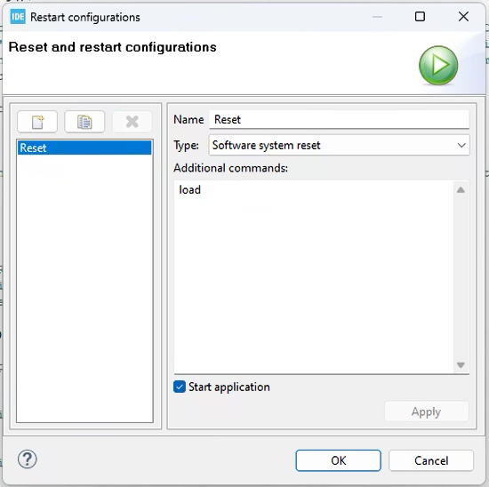

In IAR, this package provides a project that loads a macro to perform reload at system reset. Without this macro, please make sure to select a software reset rather than a system reset as illustrated below.

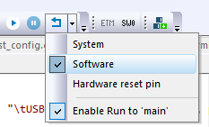

## Known Limitations

The flashing process sometimes fails. In such cases, please unplug the chosen USB supply cable and replug it. Retry to flash; it should work, otherwise repeat the operation.

The `ac audio` command will fail in dev boot configuration. However, it is applied so that the new audio configuration is usable after a reload. It is okay to use it in flash boot configuration.

Information in this document is provided solely in connection with ST products. The contents of this document are subject to change without prior notice. © Copyright STMicroelectronics 2024. All rights reserved. www.st.com